# DM_Project

### EmploymentStatus

```r
# EmploymentStatus with CLV:
pivot(data = Insurance_df, compute = c(mean,sum), variable = Customer.Lifetime.Value, by = EmploymentStatus )
```

```
##   EmploymentStatus Customer.Lifetime.Value_n Customer.Lifetime.Value_na
## 1         Disabled                       405                          0
## 2         Employed                      5698                          0
## 3    Medical Leave                       432                          0
## 4          Retired                       282                          0
## 5       Unemployed                      2317                          0
##   Customer.Lifetime.Value_mean Customer.Lifetime.Value_sum
## 1                     7847.889                     3178395
## 2                     8219.118                    46832533
## 3                     7641.822                     3301267
## 4                     7487.865                     2111578
## 5                     7636.320                    17693353
```

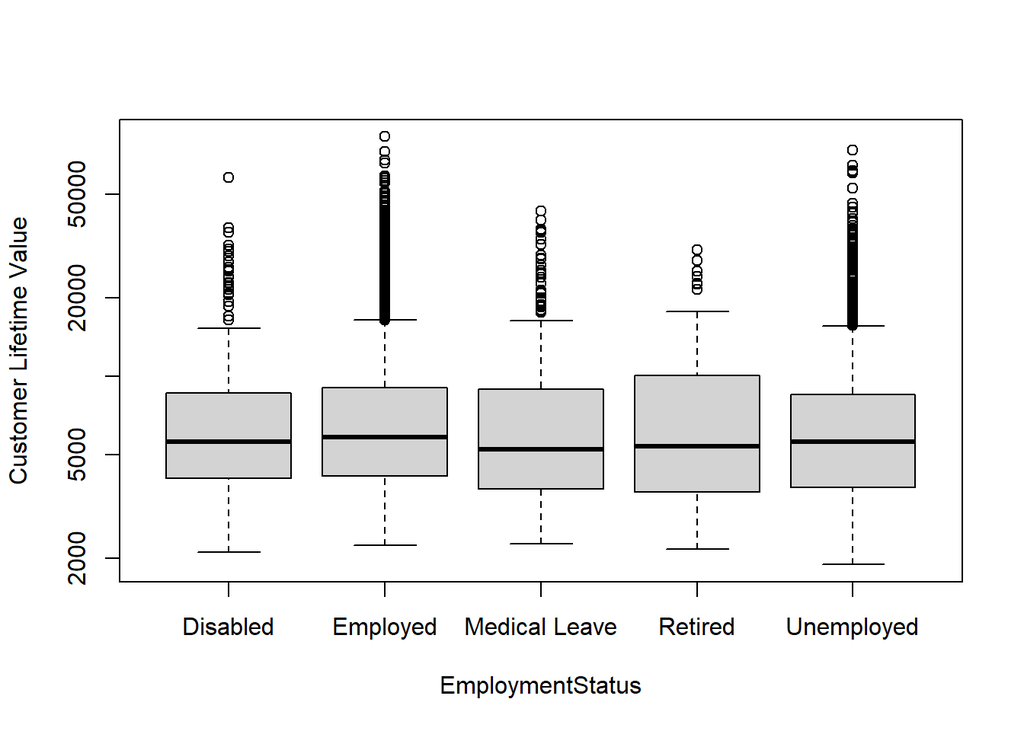

```r
boxplot(Insurance_df$Customer.Lifetime.Value ~ Insurance_df$EmploymentStatus, xlab = "EmploymentStatus", ylab = "Customer Lifetime Value", log = 'y' )
```

```r
# EmploymentStatus with Response:
Insurance_df %>%
  count(Response, EmploymentStatus) #Pivot table for Response and EmploymentStatus
```

```
##    Response EmploymentStatus    n
## 1        No         Disabled  333
## 2        No         Employed 4942
## 3        No    Medical Leave  354
## 4        No          Retired   78
## 5        No       Unemployed 2119
## 6       Yes         Disabled   72
## 7       Yes         Employed  756
## 8       Yes    Medical Leave   78
## 9       Yes          Retired  204
## 10      Yes       Unemployed  198
```

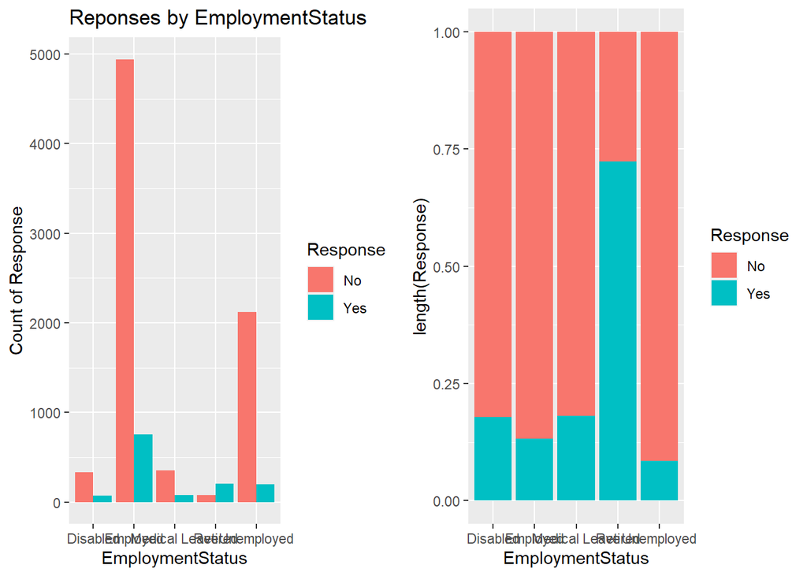

```r
EmploymentStatus.Plot1 <- ggplot(Insurance_df, aes(x = EmploymentStatus, fill = Response)) +
  geom_bar(position = "dodge") + labs(y="Count of Response",title="Reponses by EmploymentStatus")

EmploymentStatus.Plot2 <-ggplot(Insurance_df, aes(x = EmploymentStatus, y = length(Response), fill = Response)) +
  geom_col(position = "fill")  #Proportion between YES and NO
grid.arrange(EmploymentStatus.Plot1, EmploymentStatus.Plot2, ncol=2)
```

### Gender

```r
# Gender with CLV:
pivot(data = Insurance_df, compute = c(mean,sum), variable = Customer.Lifetime.Value, by = Gender )
```

```
##   Gender Customer.Lifetime.Value_n Customer.Lifetime.Value_na
## 1      F                      4658                          0
## 2      M                      4476                          0
##   Customer.Lifetime.Value_mean Customer.Lifetime.Value_sum
## 1                     8096.602                    37713974
## 2                     7909.551                    35403152
```

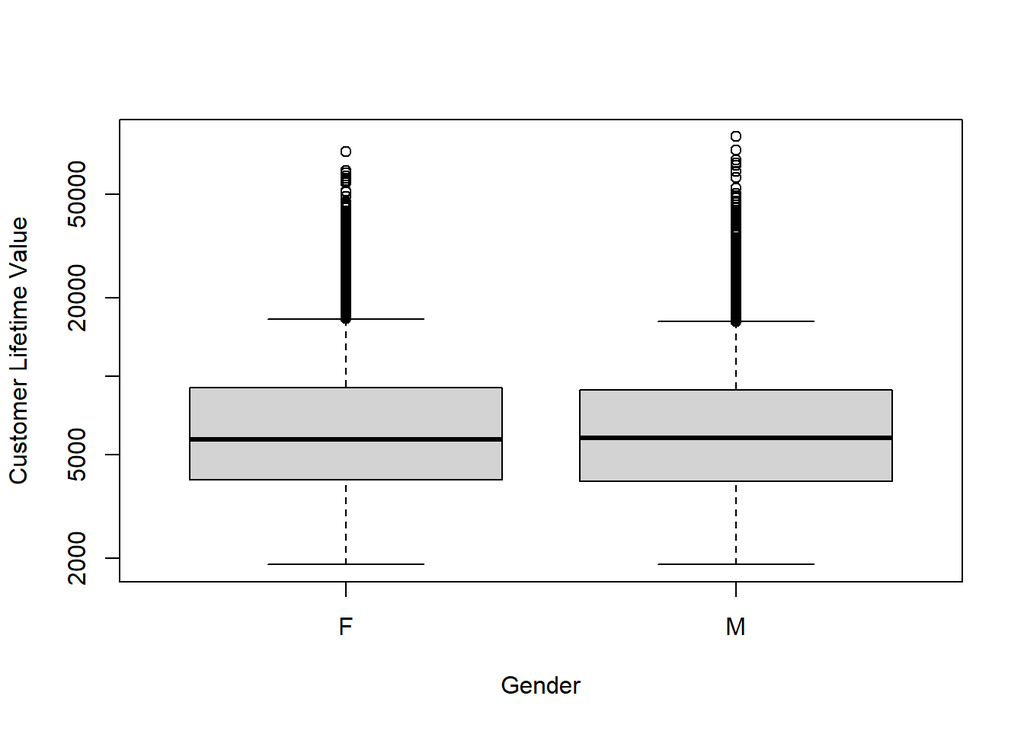

```r
boxplot(Insurance_df$Customer.Lifetime.Value ~ Insurance_df$Gender, xlab = "Gender", ylab = "Customer Lifetime Value", log = 'y' )
```

```r
# Gender with Response:
Insurance_df %>%
  count(Response, Gender) #Pivot table for Response and Gender
```

```
##   Response Gender    n
## 1       No      F 3998
## 2       No      M 3828
## 3      Yes      F  660
## 4      Yes      M  648
```

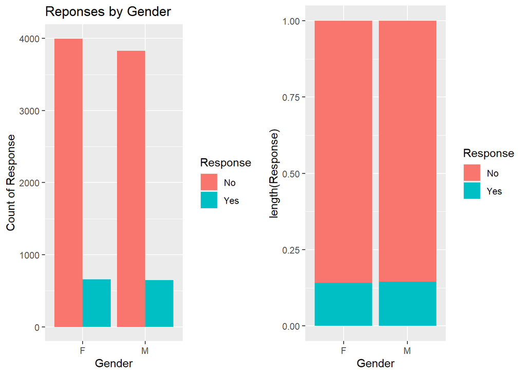

```r
Gender.Plot1 <- ggplot(Insurance_df, aes(x = Gender, fill = Response)) +
  geom_bar(position = "dodge") + labs(y="Count of Response",title="Reponses by Gender")

Gender.Plot2 <-ggplot(Insurance_df, aes(x = Gender, y = length(Response), fill = Response)) +
  geom_col(position = "fill")  #Proportion between YES and NO
grid.arrange(Gender.Plot1, Gender.Plot2, ncol=2)
```

- We can see from the boxplot and pivot table of CLV and Gender, the CLV of male and female customer are same.
- The YES/NO ratio of Male and Female customer are not much different.

### Location.Code

```r
# Location.Code with CLV:
pivot(data = Insurance_df, compute = c(mean,sum), variable = Customer.Lifetime.Value, by = Location.Code )
```

```
##   Location.Code Customer.Lifetime.Value_n Customer.Lifetime.Value_na
## 1         Rural                      1773                          0
## 2      Suburban                      5779                          0
## 3         Urban                      1582                          0
##   Customer.Lifetime.Value_mean Customer.Lifetime.Value_sum
## 1                     7953.699                    14101909
## 2                     8004.457                    46257759
## 3                     8064.133                    12757458
```

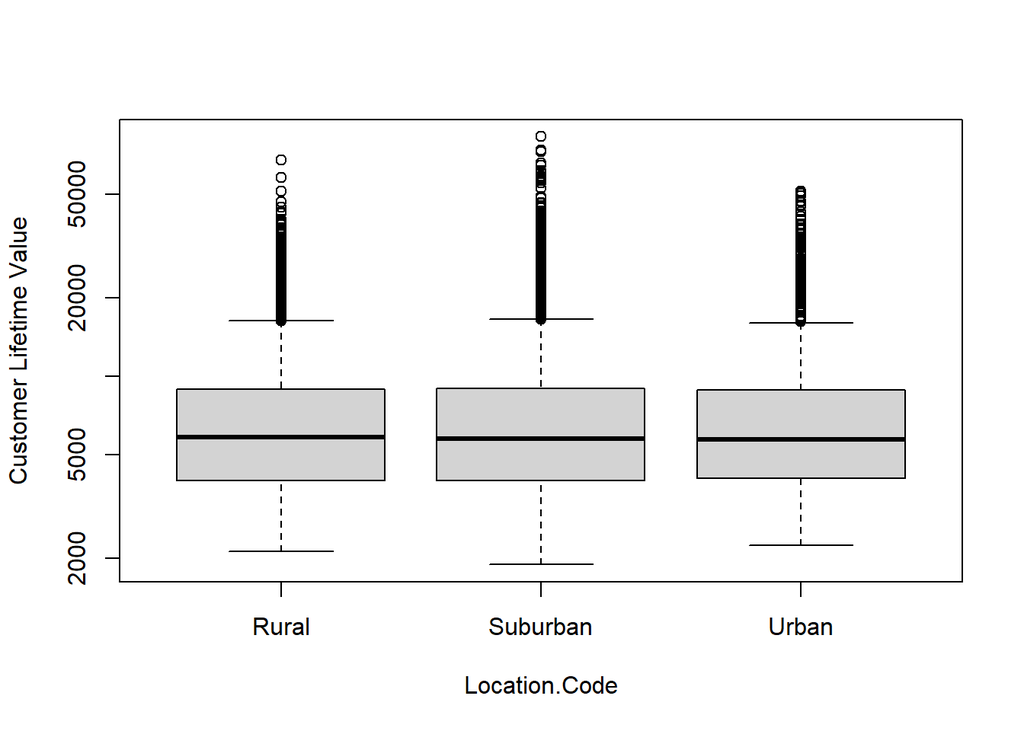

```r
boxplot(Insurance_df$Customer.Lifetime.Value ~ Insurance_df$Location.Code, xlab = "Location.Code", ylab = "Customer Lifetime Value", log = 'y' )
```

```r
# Location.Code with Response:
Insurance_df %>%
  count(Response, Location.Code) #Pivot table for Response and Location.Code
```

```
##   Response Location.Code    n
## 1       No         Rural 1611
## 2       No      Suburban 4771
## 3       No         Urban 1444
## 4      Yes         Rural  162
## 5      Yes      Suburban 1008
## 6      Yes         Urban  138
```

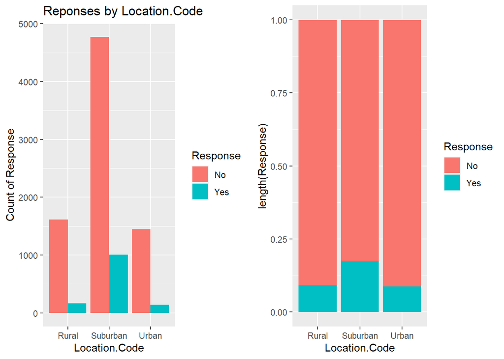

```r
Location.Code.Plot1 <- ggplot(Insurance_df, aes(x = Location.Code, fill = Response)) +
  geom_bar(position = "dodge") + labs(y="Count of Response",title="Reponses by Location.Code")

Location.Code.Plot2 <-ggplot(Insurance_df, aes(x = Location.Code, y = length(Response), fill = Response)) +
  geom_col(position = "fill")  #Proportion between YES and NO
grid.arrange(Location.Code.Plot1, Location.Code.Plot2, ncol=2)
```

- We can see from the boxplot and pivot table of CLV and Location.Code, the CLV of rural, urban, and suburban customer are same.
- The YES response ratio of Suburban customer is higher than that of Rural and Urban Customer.